# San Mateo Union High

## List of active schools

#### High School

- Aragon High
- Burlingame High
- Capuchino High
- Design Tech High
- Hillsdale High
- Mills High
- Peninsula High
- San Mateo High

#### Adult

- San Mateo Adult

## Key summary

### High School

| Name | 2015 Enrollment | API Percentile |
| --- | --- | --- |
| Aragon High | 1,473 | 90 |
| Burlingame High | 1,339 | 93 |
| Capuchino High | 1,127 | 69 |
| Design Tech High | 260 |  |
| Hillsdale High | 1,375 | 82 |
| Mills High | 1,198 | 93 |
| Peninsula High | 203 |  |
| San Mateo High | 1,615 | 78 |

### Adult

| Name | 2015 Enrollment | API Percentile |
| --- | --- | --- |
| San Mateo Adult | NA |  |

### Aragon High

- Street address: 900 Alameda de Las Pulgas
- San Mateo CA 94402-3357
- Phone: (650) 558-2999
- Website: http://https://aragon.schoolloop.com/
- Open Date: 1980-07-01
- Charter: N
- Grades Offered: 9-12
- Grades Served: 9-12
- Virtual: N
- Magnet: N

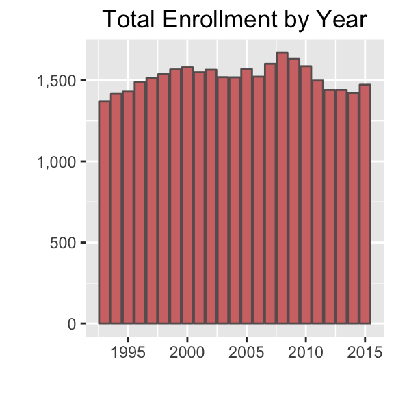

| Gender | Count | Percent |
| --- | --- | --- |
| Male | 797 | 54% |
| Female | 676 | 46% |

| Ethnicity | Count | Percent |
| --- | --- | --- |
| American Indian or Alaska Native | 4 | 0% |
| Asian | 359 | 24% |
| Pacific Islander | 49 | 3% |
| Filipino | 88 | 6% |
| Hispanic or Latino | 384 | 26% |
| African American | 17 | 1% |
| White | 406 | 28% |
| Two or More Races | 166 | 11% |

### Burlingame High

- Street address: 1 Mangini Way
- Burlingame CA 94010-2708
- Phone: (650) 558-2899
- Website: http://bhs.schoolloop.com
- Open Date: 1980-07-01
- Charter: N
- Grades Offered: 9-12
- Grades Served: 9-12
- Virtual: N
- Magnet: N

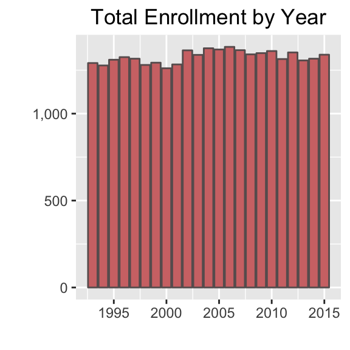

| Gender | Count | Percent |
| --- | --- | --- |
| Male | 680 | 51% |
| Female | 659 | 49% |

| Ethnicity | Count | Percent |
| --- | --- | --- |
| American Indian or Alaska Native | 2 | 0% |
| Asian | 214 | 16% |
| Pacific Islander | 13 | 1% |
| Filipino | 45 | 3% |
| Hispanic or Latino | 251 | 19% |
| African American | 11 | 1% |
| White | 701 | 52% |
| Two or More Races | 102 | 8% |

### Capuchino High

- Street address: 1501 Magnolia Avenue
- San Bruno CA 94066-5451
- Phone: (650) 558-2799
- Website: http://chs.schoolloop.com
- Open Date: 1980-07-01
- Charter: N
- Grades Offered: 9-12
- Grades Served: 9-12
- Virtual: N
- Magnet: N

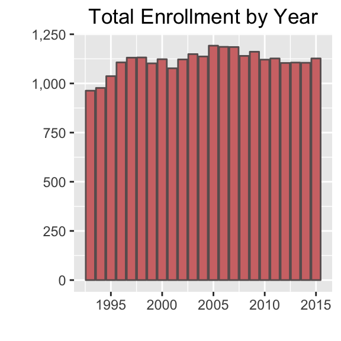

| Gender | Count | Percent |
| --- | --- | --- |
| Male | 585 | 52% |
| Female | 542 | 48% |

| Ethnicity | Count | Percent |
| --- | --- | --- |
| Asian | 123 | 11% |
| Pacific Islander | 55 | 5% |
| Filipino | 102 | 9% |
| Hispanic or Latino | 536 | 48% |
| African American | 9 | 1% |
| White | 223 | 20% |
| Two or More Races | 79 | 7% |

### Design Tech High

- Street address: 1800 Rollins Road
- Burlingame CA 94010-2205
- Phone: (650) 714-2631
- Website: http://designtechhighschool.org
- Open Date: 2014-08-01
- Charter: Y
- Grades Offered: 9-12
- Grades Served: 9-10
- Virtual: P
- Magnet: N

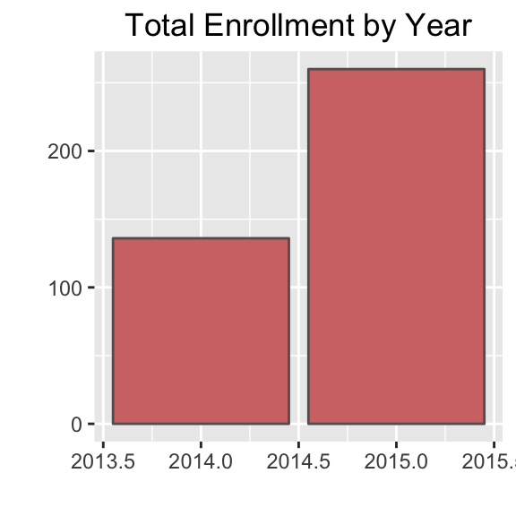

| Gender | Count | Percent |
| --- | --- | --- |
| Male | 159 | 61% |
| Female | 101 | 39% |

| Ethnicity | Count | Percent |
| --- | --- | --- |
| Not reported | 2 | 1% |
| Asian | 61 | 23% |
| Pacific Islander | 2 | 1% |
| Filipino | 10 | 4% |
| Hispanic or Latino | 52 | 20% |
| African American | 2 | 1% |
| White | 105 | 40% |
| Two or More Races | 26 | 10% |

### Hillsdale High

- Street address: 3115 Del Monte Street
- San Mateo CA 94403-3800
- Phone: (650) 558-2699
- Website: http://hhs.schoolloop.com
- Open Date: 1980-07-01
- Charter: N
- Grades Offered: 9-12
- Grades Served: 9-12
- Virtual: N
- Magnet: N

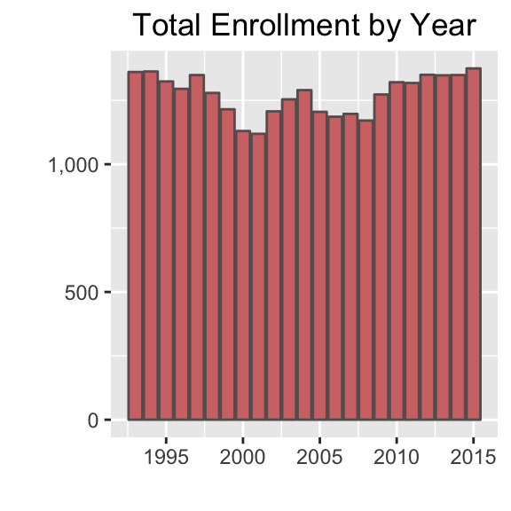

| Gender | Count | Percent |
| --- | --- | --- |
| Male | 712 | 52% |
| Female | 663 | 48% |

| Ethnicity | Count | Percent |
| --- | --- | --- |
| American Indian or Alaska Native | 5 | 0% |
| Asian | 212 | 15% |
| Pacific Islander | 20 | 1% |
| Filipino | 80 | 6% |
| Hispanic or Latino | 358 | 26% |
| African American | 19 | 1% |
| White | 556 | 40% |
| Two or More Races | 125 | 9% |

### Mills High

- Street address: 400 Murchison Drive
- Millbrae CA 94030-3024
- Phone: (650) 558-2599
- Website: http://mhs.schoolloop.com
- Open Date: 1980-07-01
- Charter: N
- Grades Offered: 9-12
- Grades Served: 9-12
- Virtual: N
- Magnet: N

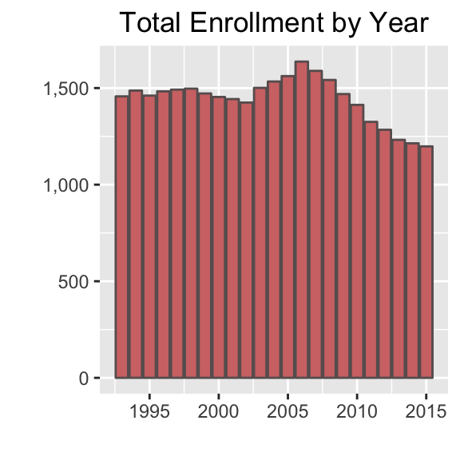

| Gender | Count | Percent |
| --- | --- | --- |
| Male | 612 | 51% |
| Female | 586 | 49% |

| Ethnicity | Count | Percent |
| --- | --- | --- |
| American Indian or Alaska Native | 1 | 0% |
| Asian | 580 | 48% |
| Pacific Islander | 26 | 2% |
| Filipino | 130 | 11% |
| Hispanic or Latino | 205 | 17% |
| African American | 2 | 0% |
| White | 168 | 14% |
| Two or More Races | 86 | 7% |

### Peninsula High

- Street address: 300 Piedmont Avenue
- San Bruno CA 94066-3906
- Phone: (650) 558-2499
- Website: http://phs-smuhsd-ca.schoolloop.com/
- Open Date: 2013-08-01
- Charter: N
- Grades Offered: 9-12
- Grades Served: 9-12
- Virtual: N
- Magnet: N

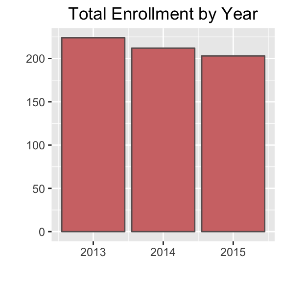

| Gender | Count | Percent |
| --- | --- | --- |
| Male | 112 | 55% |
| Female | 91 | 45% |

| Ethnicity | Count | Percent |
| --- | --- | --- |
| Asian | 10 | 5% |
| Pacific Islander | 8 | 4% |
| Filipino | 4 | 2% |
| Hispanic or Latino | 120 | 59% |
| African American | 2 | 1% |
| White | 40 | 20% |
| Two or More Races | 19 | 9% |

### San Mateo High

- Street address: 506 North Delaware Street
- San Mateo CA 94401-1700
- Phone: (650) 558-2399
- Website: www.sanmateohigh.org/
- Open Date: 1980-07-01
- Charter: N
- Grades Offered: 9-12
- Grades Served: 9-12
- Virtual: N
- Magnet: N

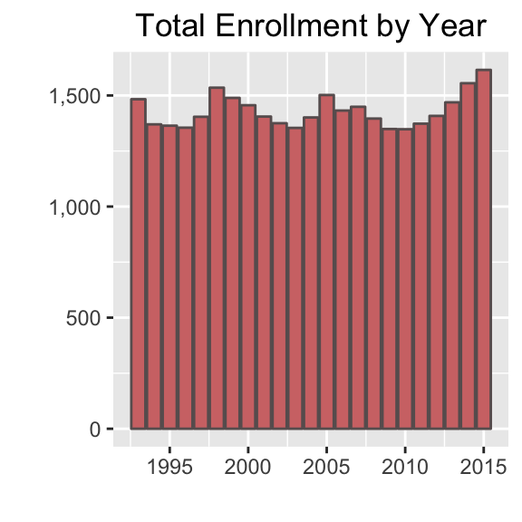

| Gender | Count | Percent |
| --- | --- | --- |
| Male | 797 | 49% |
| Female | 818 | 51% |

| Ethnicity | Count | Percent |
| --- | --- | --- |
| American Indian or Alaska Native | 3 | 0% |
| Asian | 368 | 23% |
| Pacific Islander | 40 | 2% |
| Filipino | 73 | 5% |
| Hispanic or Latino | 680 | 42% |
| African American | 21 | 1% |
| White | 311 | 19% |
| Two or More Races | 119 | 7% |

### San Mateo Adult

- Street address: 789 East Poplar Avenue
- San Mateo CA 94401-1780
- Phone: (650) 558-2100
- Website: www.smace.org
- Open Date: 1980-07-01
- Charter: N
- Grades Offered: Adult
- Grades Served: NA
- Virtual: N
- Magnet: NA